# Nadeu_2022_bulkRNA-seq_analysis

Author

Pakorn Sagulkoo

In this code we will analyse bulk RNA-seq between Richter’s transformation (RT) and chronic lymphocytic leukaemia (CLL) patients. The data comes from [Nadeu et al. (2022)](https://www.nature.com/articles/s41591-022-01927-8#data-availability). The original article performed kallisto to preprocess raw files to pseudocount files. We downloaded the original kallisto pseudocount files from this [GitHub](https://github.com/ferrannadeu/RichterTransformation/tree/main).

# Import the relevant packages and set working path directory

```r
# Import the relavant packages
library(tximport)
library(ensembldb)
library(dplyr)
library(stringr)
library(ggplot2)
library(ggrepel)
library(DESeq2)
```

```r
# Check root path
here::here()
```

```
[1] "/mnt/hp-storage/users/pakorns"
```

# Define paths

```r
# Define paths to load and save files
path_to_samples <- here::here("RNAseq/Nadeu_2022/kallisto")
path_to_sample_metadata <- here::here("RNAseq/systematic_review/1-Nadeu_2022/sample_metadata.tsv")
path_to_ref_transcriptome <- "/home/pakorns/hc-storage/fastq_files/RNAseq/transcriptome_ref"
path_to_save_txi <- here::here("RNAseq/systematic_review/1-Nadeu_2022/count_matrices/Nadeu_txi.rds")
path_to_save_dea <- here::here("RNAseq/systematic_review/1-Nadeu_2022/expression_data/Nadeu_dea.rds")
path_to_save_hm_gsea <- here::here("RNAseq/systematic_review/1-Nadeu_2022/enrichment_data/Nadeu_hm_gsea.rds")
path_to_save_go_gsea <- here::here("RNAseq/systematic_review/1-Nadeu_2022/enrichment_data/Nadeu_go_gsea.rds")
path_to_save_kegg_gsea <- here::here("RNAseq/systematic_review/1-Nadeu_2022/enrichment_data/Nadeu_kegg_gsea.rds")
path_to_save_reactome_gsea <- here::here("RNAseq/systematic_review/1-Nadeu_2022/enrichment_data/Nadeu_reactome_gsea.rds")
path_to_save_wikipath_gsea <- here::here("RNAseq/systematic_review/1-Nadeu_2022/enrichment_data/Nadeu_wikipath_gsea.rds")
```

# Load data and functions

```r
# Source functions
source(here::here("bin/utils.R"))
```

```r
# Load sample metadata
sample_metadata <- read.delim(path_to_sample_metadata, header = TRUE, stringsAsFactors = FALSE)
DT::datatable(sample_metadata, options = list(scrollX = TRUE))
```

|  | Case | Sample | SampleCodeFile | TimePoint | Diagnosis | IGHV | Material | Tissue | Purity | Library | Sequencer | SequencingCenter | PreviouslyPublished | rRNA | n_processed_kallisto |
| --- | --- | --- | --- | --- | --- | --- | --- | --- | --- | --- | --- | --- | --- | --- | --- |
| 1 | 63 | 063-10-01TR | 063-10-01TR | T1 | CLL | U-IGHV | Cryopreserved cells | Lymph node | 96 | Stranded mRNA-seq | HiSeq3000/4000 (2x76bp) | CNAG | no | 0.82 | 43430795 |
| 2 | 63 | 063-11-01TR | 063-11-01TR | T3 | RT | U-IGHV | Cryopreserved cells | Lymph node |  | Stranded mRNA-seq | HiSeq3000/4000 (2x76bp) | CNAG | no | 0.83 | 38277805 |
| 3 | 365 | 365-13-01TR | 365-13-01TR | T1 | CLL | M-IGHV | Cryopreserved cells | Lymph node | 95 | Stranded mRNA-seq | HiSeq3000/4000 (2x76bp) | CNAG | no | 1.09 | 44216995 |
| 4 | 365 | 365-14-01TR | 365-14-01TR | T3 | RT | M-IGHV | Cryopreserved cells | Lymph node | 96.4 | Stranded mRNA-seq | HiSeq3000/4000 (2x76bp) | CNAG | no | 0.87 | 39103147 |
| 5 | 3299 | 3299-03-02TR | 3299-03-02TR | T2 | CLL | U-IGHV | Cryopreserved cells | Peripheral blood | 97 | Stranded mRNA-seq | HiSeq3000/4000 (2x76bp) | CNAG | no | 1.26 | 37740216 |
| 6 | 3299 | 3299-02-02TR | 3299-02-02TR | T4 | RT | U-IGHV | Cryopreserved cells | Peripheral blood | 99 | Stranded mRNA-seq | HiSeq3000/4000 (2x76bp) | CNAG | no | 0.89 | 57520456 |
| 7 | 19 | 019-0047-02TR | 019-0047-02TR | T2 | CLL | M-IGHV | Cryopreserved cells | Peripheral blood | 99 | Stranded mRNA-seq | HiSeq3000/4000 (2x76bp) | CNAG | no | 0.21 | 93586283 |
| 8 | 19 | 019-17-01TR | 019-17-01TR | T6 | RT | M-IGHV | Cryopreserved cells | Peripheral blood | 93.5 | Stranded mRNA-seq | HiSeq3000/4000 (2x76bp) | CNAG | no | 3 | 52261244 |
| 9 | 12 | 012-02-02TR | 012-02-2TR | T2 | CLL | U-IGHV | Cryopreserved cells | Peripheral blood | 99.5 | Unstranded poly-A-based mRNA enrichment | HiSeq2000 (2x76bp) | CNAG | yes (ICGC-CLL study, Puente et al Nature 2015) | 0.91 | 41295074 |
| 10 | 12 | 012-21-01TR | 12-21-1TR | T6 | RT | U-IGHV | Cryopreserved cells | Peripheral blood | 95 | Stranded mRNA Prep, Ligation kit | NextSeq2000 (2x100bp) | IDIBAPS | no | 1.2 | 73631981 |

[output cut: 2 more lines]

```r
# Create a vector collecting kallisto results in each sample
path_to_download <- str_c(path_to_samples, "/", sample_metadata$Sample, "_abundance.tsv")
names(path_to_download) <- sample_metadata$Sample
path_to_download
```

```
                                                                           063-10-01TR
  "/mnt/hp-storage/users/pakorns/RNAseq/Nadeu_2022/kallisto/063-10-01TR_abundance.tsv"
                                                                           063-11-01TR
  "/mnt/hp-storage/users/pakorns/RNAseq/Nadeu_2022/kallisto/063-11-01TR_abundance.tsv"
                                                                           365-13-01TR
  "/mnt/hp-storage/users/pakorns/RNAseq/Nadeu_2022/kallisto/365-13-01TR_abundance.tsv"
                                                                           365-14-01TR
  "/mnt/hp-storage/users/pakorns/RNAseq/Nadeu_2022/kallisto/365-14-01TR_abundance.tsv"
                                                                          3299-03-02TR
 "/mnt/hp-storage/users/pakorns/RNAseq/Nadeu_2022/kallisto/3299-03-02TR_abundance.tsv"
                                                                          3299-02-02TR
 "/mnt/hp-storage/users/pakorns/RNAseq/Nadeu_2022/kallisto/3299-02-02TR_abundance.tsv"
                                                                         019-0047-02TR
"/mnt/hp-storage/users/pakorns/RNAseq/Nadeu_2022/kallisto/019-0047-02TR_abundance.tsv"
                                                                           019-17-01TR
  "/mnt/hp-storage/users/pakorns/RNAseq/Nadeu_2022/kallisto/019-17-01TR_abundance.tsv"
                                                                           012-02-02TR
  "/mnt/hp-storage/users/pakorns/RNAseq/Nadeu_2022/kallisto/012-02-02TR_abundance.tsv"
                                                                           012-21-01TR
  "/mnt/hp-storage/users/pakorns/RNAseq/Nadeu_2022/kallisto/012-21-01TR_abundance.tsv"
                                                                           816-01-06TR
  "/mnt/hp-storage/users/pakorns/RNAseq/Nadeu_2022/kallisto/816-01-06TR_abundance.tsv"
                                                                           816-07-01TR
  "/mnt/hp-storage/users/pakorns/RNAseq/Nadeu_2022/kallisto/816-07-01TR_abundance.tsv"
```

# Convert kallisto results to an expression matrix

```r
# Load the ensembl hg38 gtf file
path_to_hg38_transcriptome <- str_c(path_to_ref_transcriptome, "/Homo_sapiens.GRCh38.115.gtf.gz")
edb <- ensDbFromGtf(path_to_hg38_transcriptome) # Return edb = "./Homo_sapiens.GRCh38.115.sqlite"
```

```r
# Make the transcript-to-gene map (tx2gene)
edb <- here::here("RNAseq/systematic_review/1-Nadeu_2022/Homo_sapiens.GRCh38.115.sqlite")
edb_obj <- EnsDb(edb)
tx2gene <- transcripts(edb_obj,
                       columns = c("tx_id","gene_id","gene_name"),
                       return.type="DataFrame")

# convert to a plain data.frame for tximport
tx2gene <- as.data.frame(tx2gene)
head(tx2gene)
```

```
            tx_id         gene_id gene_name
1 ENST00000000233 ENSG00000004059      ARF5
2 ENST00000000412 ENSG00000003056      M6PR
3 ENST00000000442 ENSG00000173153     ESRRA
4 ENST00000001008 ENSG00000004478     FKBP4
5 ENST00000001146 ENSG00000003137   CYP26B1
6 ENST00000002125 ENSG00000003509   NDUFAF7
```

```r
# Load pseudocount files
txi <- tximport(path_to_download,
                type = "kallisto",
                tx2gene = tx2gene,
                ignoreTxVersion = TRUE
               )

# This gives you txi$counts, txi$abundance (TPM), txi$length
head(txi$counts)
```

```
                063-10-01TR 063-11-01TR 365-13-01TR 365-14-01TR 3299-03-02TR
ENSG00000000003    28.73058    9.993353    22.45391     42.5308     33.80851
ENSG00000000005     0.00000    0.000000     0.00000      0.0000      0.00000
ENSG00000000419   850.99970  688.999400   580.00015    660.0002    789.99990
ENSG00000000457   541.70999  709.027300   906.70030    844.5629    215.37609
ENSG00000000460   700.64893  907.090301   642.70616    632.6363    335.05433
ENSG00000000938  7049.00150 1253.001000  7268.00200    325.0003   4259.99800
                3299-02-02TR 019-0047-02TR 019-17-01TR 012-02-02TR 012-21-01TR
ENSG00000000003     38.10799      27.88048    22.52269    27.75416    76.91736
ENSG00000000005      0.00000       0.00000     0.00000     0.00000     0.00000
ENSG00000000419    831.99995    1724.00222   767.00006   533.99925  1619.99591
ENSG00000000457   1397.84000    1968.19330  1238.82100   475.32300  1035.20094
ENSG00000000460    710.60028     597.02730  1031.46056   610.04114   909.67961
ENSG00000000938  11328.00260   28643.99390  8102.99860 12028.00090 10032.00285
                816-01-06TR 816-07-01TR
ENSG00000000003     22.9470     11.7624
ENSG00000000005      0.0000      0.0000
ENSG00000000419    593.9995    480.0003
ENSG00000000457    436.9430    561.6987
ENSG00000000460    715.7782    326.6687
ENSG00000000938  12592.9905   2132.0000
```

```r
# Save the expression file
saveRDS(txi, path_to_save_txi)
```

# Transcriptomics analysis using DESeq2

```r
# Import the relevant package
library(DESeq2)
library(limma)
```

## Create a DESeq2 object

```r
# Create metadata for DESeq2 object
colData <- sample_metadata[, c("Sample", "Diagnosis", "Case")] %>%
  rename(
    samples = "Sample",
    condition = "Diagnosis",
    case = "Case"
  ) %>%
  mutate(
    batch = ifelse(case == "63", 1,
                   ifelse(case == "365", 2,
                          ifelse(case == "3299", 3,
                                 ifelse(case == "19", 4,
                                        ifelse(case == "12", 5, 6)))))
  )

rownames(colData) <- colData$samples
colData$condition <- factor(colData$condition)
colData$batch <- factor(colData$batch)
colData
```

```
                    samples condition case batch
063-10-01TR     063-10-01TR       CLL   63     1
063-11-01TR     063-11-01TR        RT   63     1
365-13-01TR     365-13-01TR       CLL  365     2
365-14-01TR     365-14-01TR        RT  365     2
3299-03-02TR   3299-03-02TR       CLL 3299     3
3299-02-02TR   3299-02-02TR        RT 3299     3
019-0047-02TR 019-0047-02TR       CLL   19     4
019-17-01TR     019-17-01TR        RT   19     4
012-02-02TR     012-02-02TR       CLL   12     5
012-21-01TR     012-21-01TR        RT   12     5
816-01-06TR     816-01-06TR       CLL  816     6
816-07-01TR     816-07-01TR        RT  816     6
```

```r
# Create the object
dds <- DESeqDataSetFromTximport(txi, colData, ~ batch + condition)
```

```r
# Keep genes with at least 10 counts across all samples
keep <- rowSums(counts(dds)) >= 10
dds <- dds[keep,]

# Run DESeq2
dds$condition <- relevel(dds$condition, ref = "CLL")
dds <- DESeq(dds)
```

## Plot the PCA based on the expression data

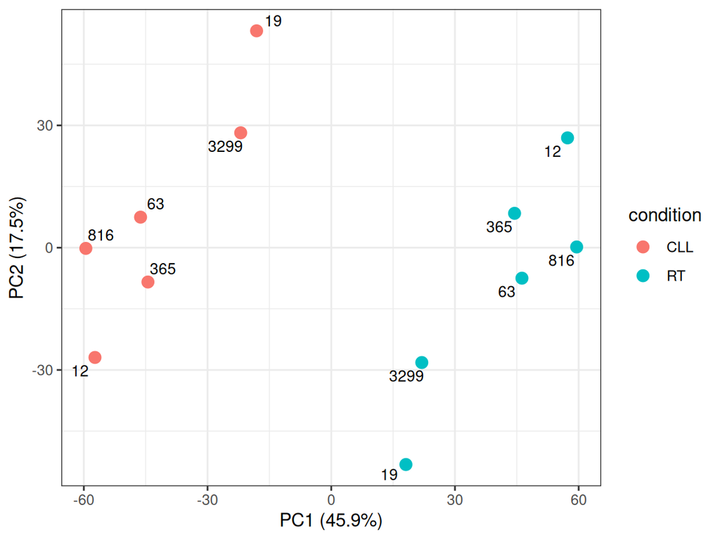

```r
# Variance stabilised transformation
vsdata <- vst(dds, blind = FALSE)

# Extract matrix
vs_mat <- assay(vsdata)

# Adjust for batch (assume batch info is in colData(dds)$batch)
vs_mat_corrected <- removeBatchEffect(vs_mat, batch = colData(dds)$batch)

# PCA on corrected data
pca <- prcomp(t(vs_mat_corrected))

# Calculate % variance explained
pca_var <- pca$sdev^2               # variance of each PC
pca_var_percent <- pca_var / sum(pca_var) * 100

# Create case name
case <- sub("^0*", "", sub("-.*$", "", rownames(colData(dds))))

# Make a dataframe for ggplot
pca_df <- data.frame(pca$x,
                     condition = colData(dds)$condition,
                     sample = case)

# Plot
pca.plt <- ggplot(pca_df, aes(PC1, PC2, color=condition, label=sample)) +
  geom_point(size = 3) +
  geom_text_repel(size=3.25, color = "black") +
  xlab(paste0("PC1 (", round(pca_var_percent[1], 1), "%)")) +
  ylab(paste0("PC2 (", round(pca_var_percent[2], 1), "%)")) +
  theme_bw()

pca.plt
```

After batch correction using `limma()`, we can see that the samples were grouped based on the conditions rather than the case origin.

## Differential gene expression analysis

```r
# Generate a table for gene expression
res <- lfcShrink(dds,
                 contrast = c("condition", "RT", "CLL"),
                 type = 'normal')
head(res)
```

```
log2 fold change (MAP): condition RT vs CLL
Wald test p-value: condition RT vs CLL
DataFrame with 6 rows and 6 columns
                 baseMean log2FoldChange     lfcSE      stat      pvalue
                <numeric>      <numeric> <numeric> <numeric>   <numeric>
ENSG00000000003   29.8326     -0.0766159  0.445903 -0.230708 0.817541275
ENSG00000000419  792.8604     -0.1079432  0.263156 -0.411082 0.681012530
ENSG00000000457  789.2644      0.4830166  0.305022  1.606444 0.108176352
ENSG00000000460  672.3274      0.2884984  0.276595  1.053471 0.292125209
ENSG00000000938 7864.6164     -1.4935398  0.437186 -3.779120 0.000157384
ENSG00000000971   13.7457      0.5351185  0.558328  0.955641 0.339253646
                      padj
                 <numeric>
ENSG00000000003 0.91015240
ENSG00000000419 0.83150322
ENSG00000000457 0.27381670
ENSG00000000460 0.51584761
ENSG00000000938 0.00214989
ENSG00000000971 0.56285264
```

```r
# Add gene names to a column in expression result
dea.df <- res
gene_map <- unique(tx2gene[, c("gene_id", "gene_name")])
dea.df$gene_id <- rownames(dea.df)
dea.df$gene_name <- gene_map$gene_name[match(rownames(dea.df), gene_map$gene_id)]
head(dea.df)
```

```
log2 fold change (MAP): condition RT vs CLL
Wald test p-value: condition RT vs CLL
DataFrame with 6 rows and 8 columns
                 baseMean log2FoldChange     lfcSE      stat      pvalue
                <numeric>      <numeric> <numeric> <numeric>   <numeric>
ENSG00000000003   29.8326     -0.0766159  0.445903 -0.230708 0.817541275
ENSG00000000419  792.8604     -0.1079432  0.263156 -0.411082 0.681012530
ENSG00000000457  789.2644      0.4830166  0.305022  1.606444 0.108176352
ENSG00000000460  672.3274      0.2884984  0.276595  1.053471 0.292125209
ENSG00000000938 7864.6164     -1.4935398  0.437186 -3.779120 0.000157384
ENSG00000000971   13.7457      0.5351185  0.558328  0.955641 0.339253646
                      padj         gene_id   gene_name
                 <numeric>     <character> <character>
ENSG00000000003 0.91015240 ENSG00000000003      TSPAN6
ENSG00000000419 0.83150322 ENSG00000000419        DPM1
ENSG00000000457 0.27381670 ENSG00000000457       SCYL3
ENSG00000000460 0.51584761 ENSG00000000460       FIRRM
ENSG00000000938 0.00214989 ENSG00000000938         FGR
ENSG00000000971 0.56285264 ENSG00000000971         CFH
```

```r
# Save the expression result
saveRDS(dea.df, path_to_save_dea)
```

## Plot heatmap of gene expression

```r
# Import the relevant package
library(pheatmap)
library(RColorBrewer)
```

```r
# Data transformation
vsd <- vst(dds, blind=FALSE)       # Variance-stabilizing transformation
#rld <- rlog(dds_filtered, blind=FALSE)      # Regularized log transformation

# Extract transformed expression matrix
expr_mat <- assay(vsd)

# Calculate z-scores
zscore_mat <- t(scale(t(expr_mat)))
```

```r
# Extract main and sub- clusters info from column names
RT_sample <- sample_metadata[sample_metadata$Diagnosis == "RT", "Sample"]
conditions <-  ifelse(colnames(zscore_mat) %in% RT_sample, "RT", "CLL")
patient_id <- sub("^0*", "", sub("-.*$", "", colnames(zscore_mat)))

# Create annotation dataframe
annotation_col <- data.frame(
  Condition = factor(conditions, levels = c("CLL", "RT")),
  Case = factor(patient_id, levels = c("63","365","3299","19","12", "816"))
)
annotation_col <- annotation_col[, c("Case", "Condition")]
rownames(annotation_col) <- colnames(zscore_mat)

# Order by Condition and then Case
order_cols <- order(annotation_col$Condition, annotation_col$Case)
zscore_mat_ordered <- zscore_mat[, order_cols]
annotation_col_ordered <- annotation_col[order_cols, , drop = FALSE]
```

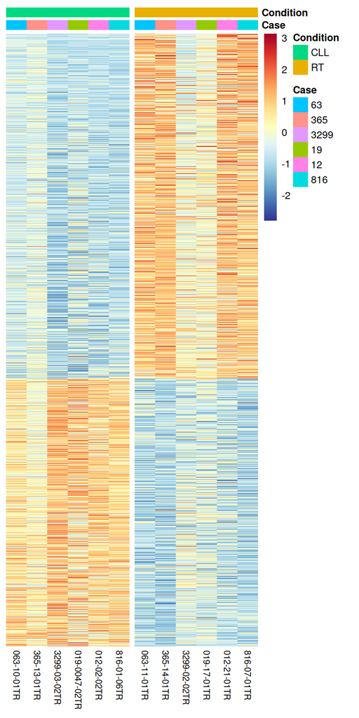

```r
# Filter for significant DE genes
sig_genes <- dea.df[!is.na(dea.df$padj) & dea.df$padj < 0.05, ]

# Order genes by log2FoldChange (descending: up -> down)
gene_order <- sig_genes$gene_id[order(sig_genes$log2FoldChange, decreasing = TRUE)]

# Subset zscore matrix
zscore_mat_sig <- zscore_mat_ordered[gene_order, ]

# Plot heatmap
pheatmap(
  zscore_mat_sig,
  cluster_rows = FALSE,
  cluster_cols = FALSE,
  show_rownames = FALSE,
  color = colorRampPalette(rev(brewer.pal(11, "RdYlBu")))(100),
  annotation_col = annotation_col_ordered,
  fontsize = 8,
  fontsize_row = 7,
  fontsize_col = 7,
  gaps_col = which(diff(as.numeric(factor(annotation_col_ordered$Condition))) != 0)
)
```

## Volcano plot

```r
# Import the package
library(EnhancedVolcano)
```

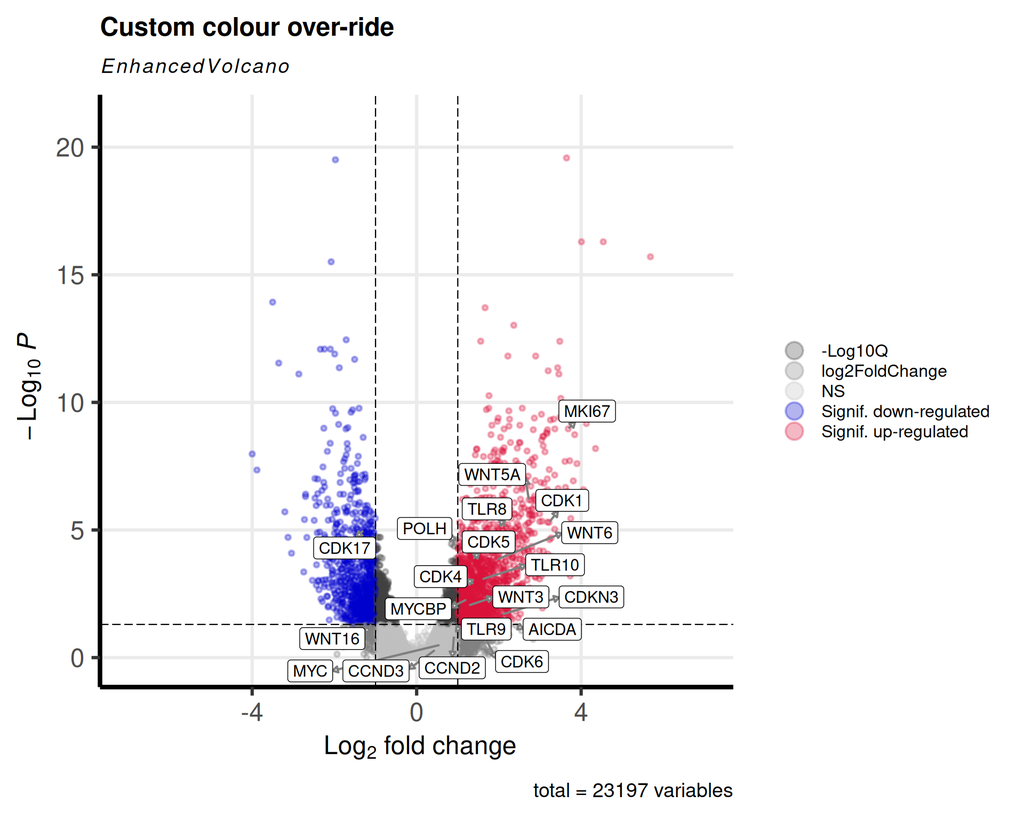

```r
# Plot volcano
genes <- c("MKI67", "CDK1", "CDK4","CDK5","CDK6","CDKN3","CDK17",
           "WNT3", "WNT5A", "WNT6", "WNT16", "TLR8", "TLR9", "TLR10",
           "AICDA", "POLH", "MYC", "MYCBP", "CCND2", "CCND3")

dea_plt <- as.data.frame(dea.df)
idx <- match(genes, dea_plt$gene_name)
rownames(dea_plt)[idx] <- dea_plt$gene_name[idx]

volcano.plt <- volcano_plot(dea_plt,
                            xlim=c(-7,7),
                            ylim=c(-0.1,21),
                            genes_of_interest = genes,
                            boxedLabels = TRUE)

volcano.plt
```

# Gene Set Enrichment Analysis (GSEA)

```r
# Import the related libraries in functional enrichment analysis
library(clusterProfiler)
library(enrichplot)
library(msigdbr)
library(org.Hs.eg.db)
```

```r
# Manipulate the expression data
lfc_vector <- dea.df$log2FoldChange # Create a named vector ranked based on the log2 fold change
names(lfc_vector) <- rownames(dea.df)
lfc_vector <- na.omit(lfc_vector) # Omit any NA values
lfc_vector <- sort(lfc_vector, decreasing = TRUE) # Sort the log2 fold change in descending order
```

### Hallmark

```r
# Hallmark
HM_gsea <- HM_GSEA(lfc_vector, gene_ident = "ensembl_gene")

# Collect the HM GSEA result
HM_GSEA.result <- HM_gsea@result
HM_GSEA_selected.result <- HM_GSEA.result %>%
  as_tibble() %>%
  dplyr::select(c(Description, NES, pvalue, p.adjust))

DT::datatable(HM_GSEA_selected.result, options = list(scrollX = TRUE))
```

|  | Description | NES | pvalue | p.adjust |
| --- | --- | --- | --- | --- |
| 1 | HALLMARK_E2F_TARGETS | 2.847574344259077 | 1.01578429586179e-32 | 5.078921479308952e-31 |
| 2 | HALLMARK_G2M_CHECKPOINT | 2.563526782436498 | 1.551470179613771e-22 | 3.878675449034427e-21 |
| 3 | HALLMARK_TNFA_SIGNALING_VIA_NFKB | -2.312618919014256 | 6.523736317255038e-14 | 1.087289386209173e-12 |
| 4 | HALLMARK_OXIDATIVE_PHOSPHORYLATION | 2.249787027823969 | 2.784071019754838e-13 | 3.480088774693547e-12 |
| 5 | HALLMARK_MYC_TARGETS_V1 | 2.191862238193307 | 4.050110430292339e-12 | 4.05011043029234e-11 |
| 6 | HALLMARK_GLYCOLYSIS | 2.072430882345179 | 1.069683739203904e-09 | 8.914031160032537e-09 |
| 7 | HALLMARK_MTORC1_SIGNALING | 1.959022902698049 | 2.678155990105595e-08 | 1.912968564361139e-07 |
| 8 | HALLMARK_MYC_TARGETS_V2 | 2.134804672754759 | 6.725442497267232e-07 | 4.20340156079202e-06 |
| 9 | HALLMARK_MITOTIC_SPINDLE | 1.842795459683296 | 1.216381535270038e-06 | 6.757675195944658e-06 |
| 10 | HALLMARK_DNA_REPAIR | 1.849996974943689 | 8.431610647537157e-06 | 4.215805323768578e-05 |

[output cut: 12 more lines]

We will explore the trends of hallmark terms reported from other single-cell pseudobulk studies such as Nadeu et al. (2022) and Hing et al (2023). From those studies, the terms such as E2F targets, Myc targets, and oxidative phosphorylation (OXPHOS) were upregulated.

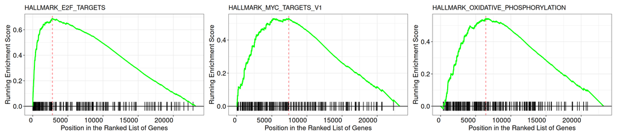

```r
# GSEA plot for HALLMARK_E2F_TARGETS, HALLMARK_MYC_TARGETS_V1, and HALLMARK_OXIDATIVE_PHOSPHORYLATION

E2F_gsea.plt <- gseaplot(HM_gsea,
                          by = "runningScore",
                          title = "HALLMARK_E2F_TARGETS",
                          geneSetID = "HALLMARK_E2F_TARGETS",
                          base_size = 10) +
  theme(axis.text.x = element_text(angle = 0, hjust = 1))

Myc_gsea.plt <- gseaplot(HM_gsea,
                          by = "runningScore",
                          title = "HALLMARK_MYC_TARGETS_V1",
                          geneSetID = "HALLMARK_MYC_TARGETS_V1",
                          base_size = 10) +
  theme(axis.text.x = element_text(angle = 0, hjust = 1))

OXPHOS_gsea.plt <- gseaplot(HM_gsea,
                          by = "runningScore",
                          title = "HALLMARK_OXIDATIVE_PHOSPHORYLATION",
                          geneSetID = "HALLMARK_OXIDATIVE_PHOSPHORYLATION",
                          base_size = 10) +
  theme(axis.text.x = element_text(angle = 0, hjust = 1))

E2F_gsea.plt + Myc_gsea.plt + OXPHOS_gsea.plt
```

### GO:BP

```r
# GO:BP
GOBP_gsea <- GO_GSEA(lfc_vector, gene_ident = "ensembl_gene")

# Collect the GSEA result
GOBP_GSEA.result <- GOBP_gsea@result
GOBP_GSEA_selected.result <- GOBP_GSEA.result %>%
  as_tibble() %>%
  dplyr::select(c(Description, NES, pvalue, p.adjust))

DT::datatable(GOBP_GSEA_selected.result, options = list(scrollX = TRUE))
```

|  | Description | NES | pvalue | p.adjust |
| --- | --- | --- | --- | --- |
| 1 | GOBP_ORGANELLE_FISSION | 2.041658452905008 | 5.342554697048019e-17 | 1.541861285568058e-13 |
| 2 | GOBP_CHROMOSOME_SEGREGATION | 2.055192120549834 | 2.707429783731868e-16 | 3.906821177925086e-13 |
| 3 | GOBP_MITOTIC_SISTER_CHROMATID_SEGREGATION | 2.315304611169825 | 2.607877646809347e-15 | 2.350520072418697e-12 |
| 4 | GOBP_NUCLEAR_CHROMOSOME_SEGREGATION | 2.134069641751742 | 3.257824078196392e-15 | 2.350520072418697e-12 |
| 5 | GOBP_SISTER_CHROMATID_SEGREGATION | 2.23885074684086 | 5.022983812815742e-15 | 2.416055213964372e-12 |
| 6 | GOBP_MITOTIC_NUCLEAR_DIVISION | 2.202758332221812 | 4.662734930270229e-15 | 2.416055213964372e-12 |
| 7 | GOBP_NUCLEOSIDE_PHOSPHATE_BIOSYNTHETIC_PROCESS | 2.135610535233407 | 6.458668215468642e-14 | 2.662816638548929e-11 |
| 8 | GOBP_DNA_TEMPLATED_DNA_REPLICATION | 2.312445423231264 | 8.3697158503172e-14 | 2.892266953786987e-11 |
| 9 | GOBP_AEROBIC_RESPIRATION | 2.278462081388174 | 9.019543514928235e-14 | 2.892266953786987e-11 |
| 10 | GOBP_RIBOSE_PHOSPHATE_BIOSYNTHETIC_PROCESS | 2.19143267187011 | 1.097268604512309e-13 | 3.166717192622526e-11 |

[output cut: 248 more lines]

We will also explore the trends of GO:BP terms reported from other single-cell studies such as Nadeu et al. (2022) and Hing et al (2023). From those studies, the terms such as OXPHOS and mitochondrial translation were upregulated while BCR signalling was downregulated.

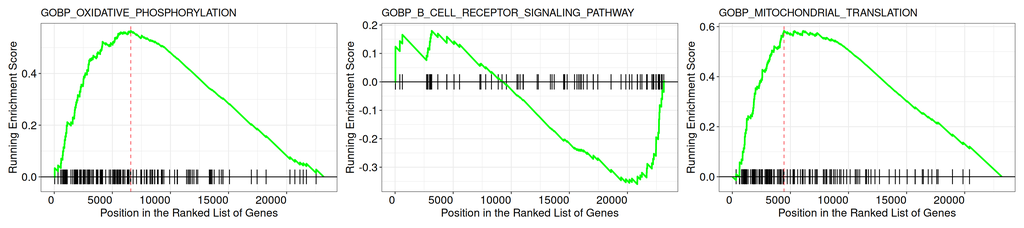

```r
# GSEA plot for GOBP_OXIDATIVE_PHOSPHORYLATION, GOBP_B_CELL_RECEPTOR_SIGNALING_PATHWAY, and GOBP_MITOCHONDRIAL_TRANSLATION

OXPHOS_GO_gsea.plt <- gseaplot(GOBP_gsea,
                          by = "runningScore",
                          title = "GOBP_OXIDATIVE_PHOSPHORYLATION",
                          geneSetID = "GOBP_OXIDATIVE_PHOSPHORYLATION",
                          base_size = 10) +
  theme(axis.text.x = element_text(angle = 0, hjust = 1))

BCR_GO_gsea.plt <- gseaplot(GOBP_gsea,
                          by = "runningScore",
                          title = "GOBP_B_CELL_RECEPTOR_SIGNALING_PATHWAY",
                          geneSetID = "GOBP_B_CELL_RECEPTOR_SIGNALING_PATHWAY",
                          base_size = 10) +
  theme(axis.text.x = element_text(angle = 0, hjust = 1))

mitochondrial_GO_gsea.plt <- gseaplot(GOBP_gsea,
                          by = "runningScore",
                          title = "GOBP_MITOCHONDRIAL_TRANSLATION",
                          geneSetID = "GOBP_MITOCHONDRIAL_TRANSLATION",
                          base_size = 10) +
  theme(axis.text.x = element_text(angle = 0, hjust = 1))

OXPHOS_GO_gsea.plt + BCR_GO_gsea.plt + mitochondrial_GO_gsea.plt
```

We also performed GSEA with additional enrichment systems such as KEGG pathways, Reactome, and WikiPath.

### KEGG pathway

```r
# KEGG pathway
KEGG_gsea <- KEGG_GSEA(lfc_vector, gene_ident = "ensembl_gene")

# Collect the HM GSEA result
KEGG_GSEA.result <- KEGG_gsea@result
KEGG_GSEA_selected.result <- KEGG_GSEA.result %>%
  as_tibble() %>%
  dplyr::select(c(Description, NES, pvalue, p.adjust))

DT::datatable(KEGG_GSEA_selected.result, options = list(scrollX = TRUE))
```

|  | Description | NES | pvalue | p.adjust |
| --- | --- | --- | --- | --- |
| 1 | KEGG_OXIDATIVE_PHOSPHORYLATION | 2.093195893650885 | 4.171704639618246e-08 | 6.215839913031186e-06 |
| 2 | KEGG_PARKINSONS_DISEASE | 2.033089749098579 | 1.556428179673968e-07 | 1.159538993857106e-05 |
| 3 | KEGG_CELL_CYCLE | 2.046964551371802 | 3.996943917275808e-07 | 1.985148812246985e-05 |
| 4 | KEGG_PYRIMIDINE_METABOLISM | 2.075973671516958 | 7.313138604240859e-07 | 2.72414413007972e-05 |
| 5 | KEGG_BASE_EXCISION_REPAIR | 2.172971735103519 | 3.296915655752491e-06 | 8.187340545118685e-05 |
| 6 | KEGG_PURINE_METABOLISM | 1.88515866776309 | 2.858636273225049e-06 | 8.187340545118685e-05 |
| 7 | KEGG_DNA_REPLICATION | 2.082329871444345 | 8.432487086711444e-06 | 0.0001615566755079039 |
| 8 | KEGG_BASAL_CELL_CARCINOMA | 2.042559064320666 | 8.674183919887458e-06 | 0.0001615566755079039 |
| 9 | KEGG_MAPK_SIGNALING_PATHWAY | -1.661071033325871 | 1.005446575739705e-05 | 0.0001664572664280178 |
| 10 | KEGG_VALINE_LEUCINE_AND_ISOLEUCINE_DEGRADATION | 2.055382064685696 | 2.214320869339309e-05 | 0.0002999398268468701 |

[output cut: 19 more lines]

### Reactome

```r
# REACTOME
REACTOME_gsea <- REACTOME_GSEA(lfc_vector, gene_ident = "ensembl_gene")

# Collect the HM GSEA result
REACTOME_GSEA.result <- REACTOME_gsea@result
REACTOME_GSEA_selected.result <- REACTOME_GSEA.result %>%
  as_tibble() %>%
  dplyr::select(c(Description, NES, pvalue, p.adjust))

DT::datatable(REACTOME_GSEA_selected.result, options = list(scrollX = TRUE))
```

|  | Description | NES | pvalue | p.adjust |
| --- | --- | --- | --- | --- |
| 1 | REACTOME_AEROBIC_RESPIRATION_AND_RESPIRATORY_ELECTRON_TRANSPORT | 2.166406240095375 | 3.669764689844287e-14 | 2.844067634629322e-11 |
| 2 | REACTOME_CELL_CYCLE_CHECKPOINTS | 2.046350502186567 | 2.870351224497918e-12 | 1.112261099492943e-09 |
| 3 | REACTOME_MITOCHONDRIAL_TRANSLATION | 2.335387533002406 | 2.028573759490127e-11 | 3.930361659012122e-09 |
| 4 | REACTOME_RESPIRATORY_ELECTRON_TRANSPORT | 2.214172519418003 | 1.586653291412801e-11 | 3.930361659012122e-09 |
| 5 | REACTOME_MITOTIC_G1_PHASE_AND_G1_S_TRANSITION | 2.152178385811499 | 3.412296213222974e-10 | 5.289059130495609e-08 |
| 6 | REACTOME_METABOLISM_OF_NUCLEOTIDES | 2.139771007301254 | 1.782373201978083e-08 | 2.302232052555023e-06 |
| 7 | REACTOME_ACTIVATION_OF_THE_PRE_REPLICATIVE_COMPLEX | 2.30924672264101 | 4.76509366163291e-08 | 4.616184484706881e-06 |
| 8 | REACTOME_RESOLUTION_OF_SISTER_CHROMATID_COHESION | 2.028917189668659 | 4.244367145391834e-08 | 4.616184484706881e-06 |
| 9 | REACTOME_MITOTIC_PROMETAPHASE | 1.907830822147267 | 6.257085688722856e-08 | 4.849241408760213e-06 |
| 10 | REACTOME_TRANSLATION | 1.829102265126922 | 5.704387240453573e-08 | 4.849241408760213e-06 |

[output cut: 92 more lines]

### WikiPath

```r
# WikiPath
WIKIPATH_gsea <- WIKIPATH_GSEA(lfc_vector, gene_ident = "ensembl_gene")

# Collect the HM GSEA result
WIKIPATH_GSEA.result <- WIKIPATH_gsea@result
WIKIPATH_GSEA_selected.result <- WIKIPATH_GSEA.result %>%
  as_tibble() %>%
  dplyr::select(c(Description, NES, pvalue, p.adjust))

DT::datatable(WIKIPATH_GSEA_selected.result, options = list(scrollX = TRUE))
```

|  | Description | NES | pvalue | p.adjust |
| --- | --- | --- | --- | --- |
| 1 | WP_RETINOBLASTOMA_GENE_IN_CANCER | 2.485004881550043 | 1.08111188628422e-13 | 4.486614328079514e-11 |
| 2 | WP_ELECTRON_TRANSPORT_CHAIN_OXPHOS_SYSTEM_IN_MITOCHONDRIA | 2.277410686676288 | 2.251329529135071e-10 | 4.671508772955273e-08 |
| 3 | WP_DNA_REPLICATION | 2.296684318405046 | 3.850440085831604e-08 | 5.326442118733719e-06 |
| 4 | WP_METABOLIC_REPROGRAMMING_IN_COLON_CANCER | 2.263985363997037 | 1.080373641330311e-07 | 8.967101223041578e-06 |
| 5 | WP_DNA_IRDAMAGE_AND_CELLULAR_RESPONSE_VIA_ATR | 2.166350071891831 | 8.818272349733233e-08 | 8.967101223041578e-06 |
| 6 | WP_PYRIMIDINE_METABOLISM | 2.135855225648089 | 2.443087621153929e-07 | 1.689802271298134e-05 |
| 7 | WP_CELL_CYCLE | 2.029997510322072 | 8.43682762229135e-07 | 5.001833518929872e-05 |
| 8 | WP_OXIDATIVE_PHOSPHORYLATION | 2.150524693066736 | 1.297011952521096e-06 | 6.728249503703187e-05 |
| 9 | WP_G1_TO_S_CELL_CYCLE_CONTROL | 2.088675860072246 | 1.49210635456729e-06 | 6.880268190504728e-05 |
| 10 | WP_ANGIOPOIETINLIKE_PROTEIN_8_REGULATORY_PATHWAY | -1.893131442636861 | 4.586915675468415e-06 | 0.0001903570005319392 |

[output cut: 62 more lines]

```r
# Save gene expression and GSEA data
saveRDS(HM_gsea, path_to_save_hm_gsea)
saveRDS(GOBP_gsea, path_to_save_go_gsea)
saveRDS(KEGG_gsea, path_to_save_kegg_gsea)
saveRDS(REACTOME_gsea, path_to_save_reactome_gsea)
saveRDS(WIKIPATH_gsea, path_to_save_wikipath_gsea)
```

## Bar plot summary

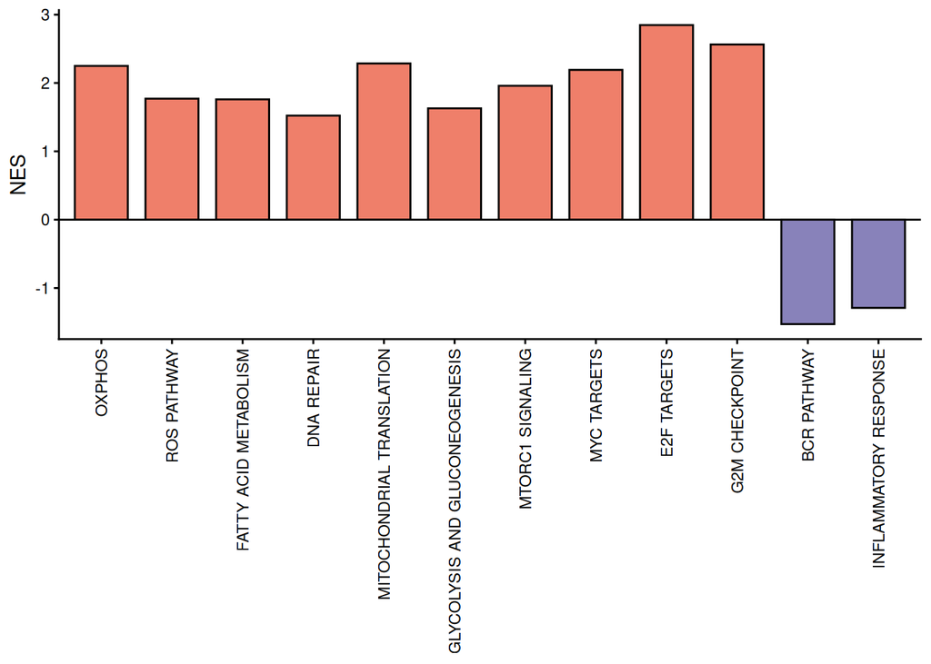

```r
# Bar plot of GSEA
gsea_bp <- rbind(HM_GSEA_selected.result[HM_GSEA_selected.result$Description == "HALLMARK_OXIDATIVE_PHOSPHORYLATION",],
                 HM_GSEA_selected.result[HM_GSEA_selected.result$Description == "HALLMARK_REACTIVE_OXYGEN_SPECIES_PATHWAY",],
                 HM_GSEA_selected.result[HM_GSEA_selected.result$Description == "HALLMARK_FATTY_ACID_METABOLISM",],
                 REACTOME_GSEA_selected.result[REACTOME_GSEA_selected.result$Description == "REACTOME_DNA_REPAIR",],
                 GOBP_GSEA_selected.result[GOBP_GSEA_selected.result$Description == "GOBP_MITOCHONDRIAL_TRANSLATION",],
                 GOBP_GSEA_selected.result[GOBP_GSEA_selected.result$Description == "GOBP_CELL_CYCLE_PHASE_TRANSITION",],
                 WIKIPATH_GSEA_selected.result[WIKIPATH_GSEA_selected.result$Description == "WP_GLYCOLYSIS_AND_GLUCONEOGENESIS",],
                 HM_GSEA_selected.result[HM_GSEA_selected.result$Description == "HALLMARK_MTORC1_SIGNALING",],
                 HM_GSEA_selected.result[HM_GSEA_selected.result$Description == "HALLMARK_MYC_TARGETS_V1",],
                 HM_GSEA_selected.result[HM_GSEA_selected.result$Description == "HALLMARK_E2F_TARGETS",],
                 HM_GSEA_selected.result[HM_GSEA_selected.result$Description == "HALLMARK_G2M_CHECKPOINT",],
                 KEGG_GSEA_selected.result[KEGG_GSEA_selected.result$Description == "KEGG_B_CELL_RECEPTOR_SIGNALING_PATHWAY",],
                 HM_GSEA_selected.result[HM_GSEA_selected.result$Description == "HALLMARK_INFLAMMATORY_RESPONSE",]
)

gsea_bp$Description <- gsub("HALLMARK_", "", gsea_bp$Description)
gsea_bp$Description <- gsub("GOBP_", "", gsea_bp$Description)
gsea_bp$Description <- gsub("KEGG_", "", gsea_bp$Description)
gsea_bp$Description <- gsub("REACTOME_", "", gsea_bp$Description)
gsea_bp$Description <- gsub("WP_", "", gsea_bp$Description)
gsea_bp$Description <- gsub("_V1", "", gsea_bp$Description)
gsea_bp$Description <- gsub("OXIDATIVE_PHOSPHORYLATION", "OXPHOS", gsea_bp$Description)
gsea_bp$Description <- gsub("REACTIVE_OXYGEN_SPECIES_PATHWAY", "ROS_PATHWAY", gsea_bp$Description)
gsea_bp$Description <- gsub("B_CELL_RECEPTOR_SIGNALING_PATHWAY", "BCR_PATHWAY", gsea_bp$Description)
gsea_bp$Description <- gsub("_", " ", gsea_bp$Description)

gsea_bp$Description <- factor(gsea_bp$Description, levels = gsea_bp$Description)
gsea_bp$Direction <- "Up"
gsea_bp$Direction[gsea_bp$NES<0] <- "Down"

gsea_bar.plt <- ggplot(gsea_bp, aes(x=Description, y=NES, fill=Direction)) +
  geom_bar(stat = "identity", color="black", width = 0.75) +
  theme_classic() +
  theme(axis.text.x = element_text(angle = 90, vjust = 0.5, hjust=1)) +
  geom_hline(yintercept = 0) +
  ylab("NES") + xlab(NULL) +
  scale_fill_manual(values=c("#8882BA", "#EF7F6A")) + theme(legend.position = "none")

gsea_bar.plt
```

## GSEA plot summary

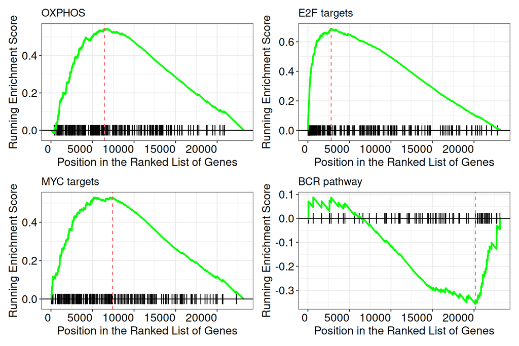

```r
# GSEA plot for HALLMARK_E2F_TARGETS, HALLMARK_MYC_TARGETS_V1, and HALLMARK_OXIDATIVE_PHOSPHORYLATION

OXPHOS_gsea.plt <- gseaplot(HM_gsea,
                          by = "runningScore",
                          title = "OXPHOS",
                          geneSetID = "HALLMARK_OXIDATIVE_PHOSPHORYLATION",
                          base_size = 10) +
  theme(axis.text.x = element_text(angle = 0, hjust = 1))

E2F_gsea.plt <- gseaplot(HM_gsea,
                          by = "runningScore",
                          title = "E2F targets",
                          geneSetID = "HALLMARK_E2F_TARGETS",
                          base_size = 10) +
  theme(axis.text.x = element_text(angle = 0, hjust = 1))

Myc_gsea.plt <- gseaplot(HM_gsea,
                          by = "runningScore",
                          title = "MYC targets",
                          geneSetID = "HALLMARK_MYC_TARGETS_V1",
                          base_size = 10) +
  theme(axis.text.x = element_text(angle = 0, hjust = 1))

BCR_gsea.plt <- gseaplot(KEGG_gsea,
                          by = "runningScore",
                          title = "BCR pathway",
                          geneSetID = "KEGG_B_CELL_RECEPTOR_SIGNALING_PATHWAY",
                          base_size = 10) +
  theme(axis.text.x = element_text(angle = 0, hjust = 1))

gsea.plt <- OXPHOS_gsea.plt + E2F_gsea.plt + Myc_gsea.plt + BCR_gsea.plt +
  plot_layout(ncol = 2)

gsea.plt
```